# PC3_ESTADÍSTICA2

2022-07-01

#PARTE 1: CONSTRUCCIÓN DE LA BASE DE DATOS

## 1. Enlace de repositorio de Github

```r
LINKREPOSITORIOGithub= "https://github.com/AlexNoblejas/PC_3_EST2"
```

## 2. Importación de los tres (03) indicadores de Protección social y trabajo del Banco Mundial (DataBank)

Enlace: https://datos.bancomundial.org/indicador?tab=all

INDICADORES SELECCIONADOS de PROTECCIÓN SOCIAL Y TRABAJO: - *Empleadores, total (% del empleo total)*

Empleadores se refiere a aquellos trabajadores que, por cuenta propia o con unos pocos asociados, mantienen el tipo de trabajo que se define como “empleo por cuenta propia”, es decir: trabajos en los que la remuneración depende directamente de las utilidades derivadas de los bienes y servicios producidos, y que, en esta capacidad, han comprometido a una o más personas para trabajar con ellos como empleado(s) de manera continua.

Fuente: Indicadores clave del mercado de trabajo ( KILM, por sus siglas en inglés ) de la OIT.

- *Empleo vulnerable, total (% del total de empleo)*

El empleo vulnerable se refiere a los trabajadores familiares no remunerados y a los trabajadores autónomos como porcentaje del empleo total.

Fuente: Organización Internacional del Trabajo, base de datos de Indicadores principales sobre el mercado laboral.

- *Población activa, total*

La población activa total comprende a personas de 15 años o más que satisfacen la definición de la Organización Internacional del Trabajo de población económicamente activa: todas las personas que aportan trabajo para la producción de bienes y servicios durante un período específico. Incluye tanto a las personas con empleo como a las personas desempleadas. Si bien las prácticas nacionales varían en el tratamiento de grupos como las fuerzas armadas o los trabajadores estacionales o a tiempo parcial, en general, la población activa incluye a las fuerzas armadas, a los desempleados, a los que buscan su primer trabajo, pero excluye a quienes se dedican al cuidado del hogar y a otros trabajadores y cuidadores no remunerados.

Fuente: Organización Internacional del Trabajo, base de datos de Indicadores principales sobre el mercado laboral.

```r
## Se toman los enlace de Github:

library(rio)
Link1='Empleadores.csv'
Link2='Empleo vulnerable.csv'
Link3='Población activa.csv'

Empleadores <- import(Link1, stringsAsFactors = F, encoding = "UTF-8")
Empleovul <- import(Link2 , stringsAsFactors = F, encoding = "UTF-8")
Poblacionact <- import(Link3, stringsAsFactors = F, encoding = "UTF-8")
```

## 3. Limpieza de las tres (03) bases de datos

### Limpieza de la Base de datos de “Empleadores”:

```r
##Conozco el número de columnas
ncol(Empleadores)
```

```
## [1] 67
```

```r
## Observo las últimas datas para ver cuál es mejor
library(dplyr)
Empleadores = Empleadores [, -c(2:63)]

## Como ahora puede observar mejor lada data, me quedo con el del año 2019

Empleadores= Empleadores [, -c(3:6)]
```

```r
##Elimino los datos perdidos

Empleadores=na.omit(Empleadores)
any(is.na(Empleadores))
```

```
## [1] FALSE
```

```r
##Elimino filas sin nombre de países
Empleadores = Empleadores[-c(1, 2,4),]
```

```r
#Asignamos nuevos nombres a las columnas
colnames (Empleadores) <- c ("Países", "Empleadores")
```

```r
#Le doy reset a los rownames
row.names(Empleadores) = NULL
```

### Limpieza de la Base de datos de “Empleo vulnerable”:

```r
##Conozco el número de columnas
ncol(Empleovul)
```

```
## [1] 67
```

```r
## Observo las últimas datas para ver cuál es mejor
library(dplyr)
Empleovul = Empleovul [, -c(2:63)]

## Como ahora puede observar mejor lada data, me quedo con el del año 2019

Empleovul= Empleovul [, -c(3:6)]
```

```r
##Elimino los datos perdidos

Empleovul=na.omit(Empleovul)
any(is.na(Empleovul))
```

```
## [1] FALSE
```

```r
##Elimino filas sin nombre de países
Empleovul = Empleovul[-c(1, 2,4),]
```

```r
#Asignamos nuevos nombres a las columnas
colnames (Empleovul) <- c ("Países", "Empleovul")
colnames (Empleovul)
```

```
## [1] "Países"    "Empleovul"
```

```r
#Le doy reset a los rownames
row.names(Empleovul) = NULL
```

### Limpieza de la Base de datos de “Población activa”:

```r
##Conozco el número de columnas
ncol(Poblacionact)
```

```
## [1] 67
```

```r
## Observo las últimas datas para ver cuál es mejor
library(dplyr)
Poblacionact = Poblacionact [, -c(2:63)]

## Como ahora puede observar mejor lada data, me quedo con el del año 2019

Poblacionact= Poblacionact [, -c(3:6)]
```

```r
##Elimino los datos perdidos

Poblacionact=na.omit(Poblacionact)
any(is.na(Poblacionact))
```

```
## [1] FALSE
```

```r
##Elimino filas sin nombre de países
Poblacionact = Poblacionact[-c(1, 2,4),]
```

```r
#Asignamos nuevos nombres a las columnas
colnames (Poblacionact) <- c ("Países", "Poblacionact")
colnames (Poblacionact)
```

```
## [1] "Países"       "Poblacionact"
```

```r
#Le doy reset a los rownames
row.names(Poblacionact) = NULL
```

## 4. Integración de la base de datos

```r
#versión INTER JOIN
alldata=merge(Poblacionact, merge(Empleadores, Empleovul, by.x='Países', by.y='Países'))
str(alldata)
```

```
## 'data.frame':    233 obs. of  4 variables:
##  $ Países      : chr  " Ingreso mediano" "Afganistán" "África al sur del Sahara" "África al sur del Sahara (BIRF y la AIF)" ...
##  $ Poblacionact:integer64 2557252941 10382034 428103634 428103634 428103634 1421853 44351163 187148235 ...
##  $ Empleadores : num  2.67 2.83 1.86 1.86 1.86 ...
##  $ Empleovul   : num  48.7 79.4 73.2 73.2 73.2 ...
```

- JUSTIFICACIÓN: En este caso se utilizó el “merge” en la versión “inter join”, debido a que en las tres (03) bases de datos que se intengró había la misma cantidad de observaciones, cada una de ellas con los mismos nombres en las tres bases de datos. Por lo tanto, al usar “merge” en su versión “inter join” no perdimos valores.

```r
# convertimos nuestras variables faltantes en numéricas
alldata$Poblacionact=as.numeric(alldata$Poblacionact)
str(alldata)
```

```
## 'data.frame':    233 obs. of  4 variables:
##  $ Países      : chr  " Ingreso mediano" "Afganistán" "África al sur del Sahara" "África al sur del Sahara (BIRF y la AIF)" ...
##  $ Poblacionact: num  2.56e+09 1.04e+07 4.28e+08 4.28e+08 4.28e+08 ...
##  $ Empleadores : num  2.67 2.83 1.86 1.86 1.86 ...
##  $ Empleovul   : num  48.7 79.4 73.2 73.2 73.2 ...
```

## 5. Creación de una variable categórica ordinal

Se plantea elaborar una variables categórica ordinal para darle sentido a los datos de nuestra tabla y nos indiquen la categoría en l que podrían estar ubicados los países respecto a la protección social y el trabajo.

En este caso usaremos el indicador del “Empleo vulnerable” para hacer una variable categórica ordinal. De manera que nos indique por niveles qué paises tiene los porcetajes más elevando de empleos vulnerables respecto al empleo total; es decir, qué países tienen más o menos trabajadores familiares no remunerados y/o trabajadores autónomos como porcentaje del empleo total.

### Elaboración de la variable categórica

Para empezar, observamos la distribución de “Empleovul” (el análisis descriptivo) y su distribución en una historigrama.

```r
#Veamos cómo está formateada:
str(alldata$Empleovul)
```

```
##  num [1:233] 48.7 79.4 73.2 73.2 73.2 ...
```

```r
summary(alldata$Empleovul)
```

```
##    Min. 1st Qu.  Median    Mean 3rd Qu.    Max.
##    0.14   13.34   33.07   38.13   62.02   94.33
```

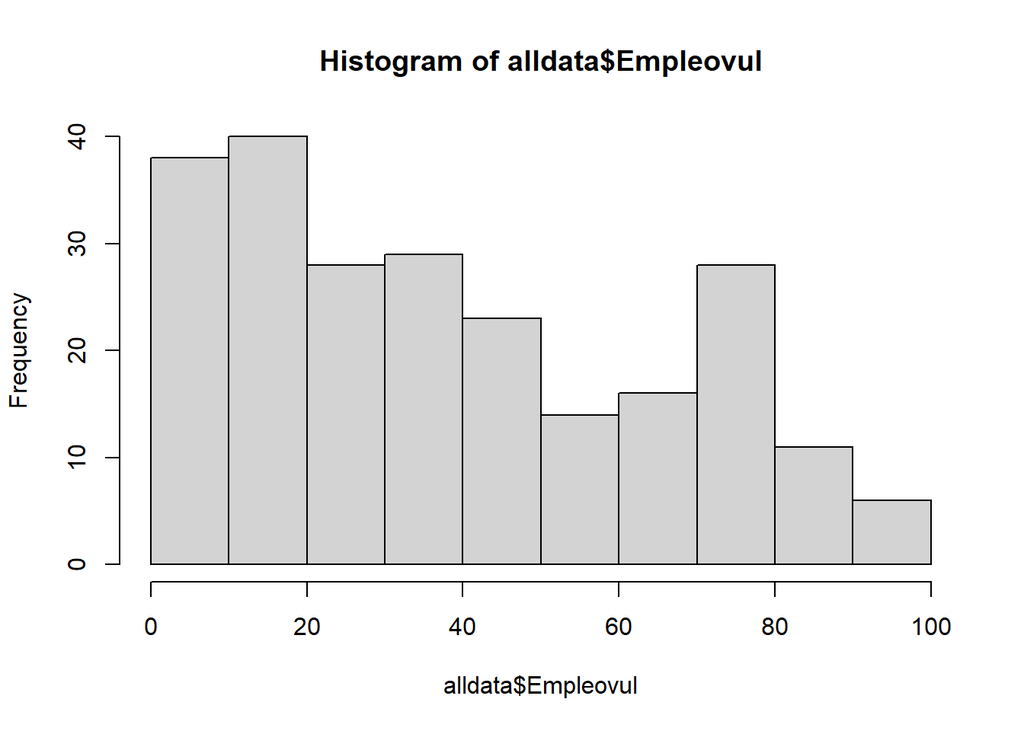

```r
hist(alldata$Empleovul)
```

- Respecto a lo observado, se ve conveniente construir intervalos con estos datos que nos indiquen el nivel del porcentaje del empleo vulnerable de cada país. Como en las ciencias sociales no podemos realizar categorías arbitrarias, recurrimos a la definición de cuántos intervalos usaremos basándonos en la fórmula “Sturges” incorporado en el programa R.

```r
alldata$Empleovul2=alldata$Empleovul
numBreaks=nclass.Sturges(na.omit(alldata$Empleovul2))
```

-> La fórmula nos indica que hay que hacer 9 intervalos:

```r
alldata$Empleovul2 = cut(alldata$Empleovul2,
                   breaks = numBreaks,
                   oredered_result = T)
```

```r
table(alldata$Empleovul2)
```

```
##
## (0.0458,10.6]   (10.6,21.1]   (21.1,31.5]     (31.5,42]     (42,52.5]
##            44            35            35            24            27
##   (52.5,62.9]   (62.9,73.4]   (73.4,83.9]   (83.9,94.4]
##            13            22            21            12
```

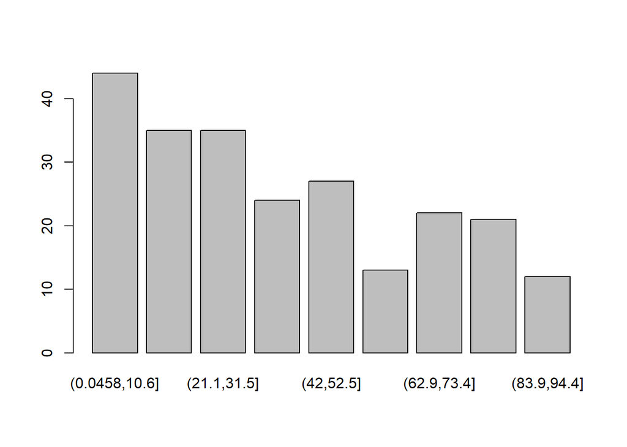

```r
barplot(table(alldata$Empleovul2))
```

- Como se observa en el histograma, tenemos nueve niveles o categorías respecto al porcetanje de empleo vulnerable en cada país. Así que procedemos a asignarles una etiqueta para tenerlo visualmente mucho más claro.

```r
breaks_Empleovul3 = c(0,10.6,21.1,31.5,42,52.5,62.9,73.4, 83.9, 100)
labels_Empleovul3 = c("Casi inexistente", "Muy bajo","Bajo", "Medio-bajo", "Medio","Medio-alto", "Alto","Muy alto", "Extremo")
alldata$Empleovul3 = cut(alldata$Empleovul,
                   breaks = breaks_Empleovul3,
                   labels = labels_Empleovul3,
                   oredered_result = T)
```

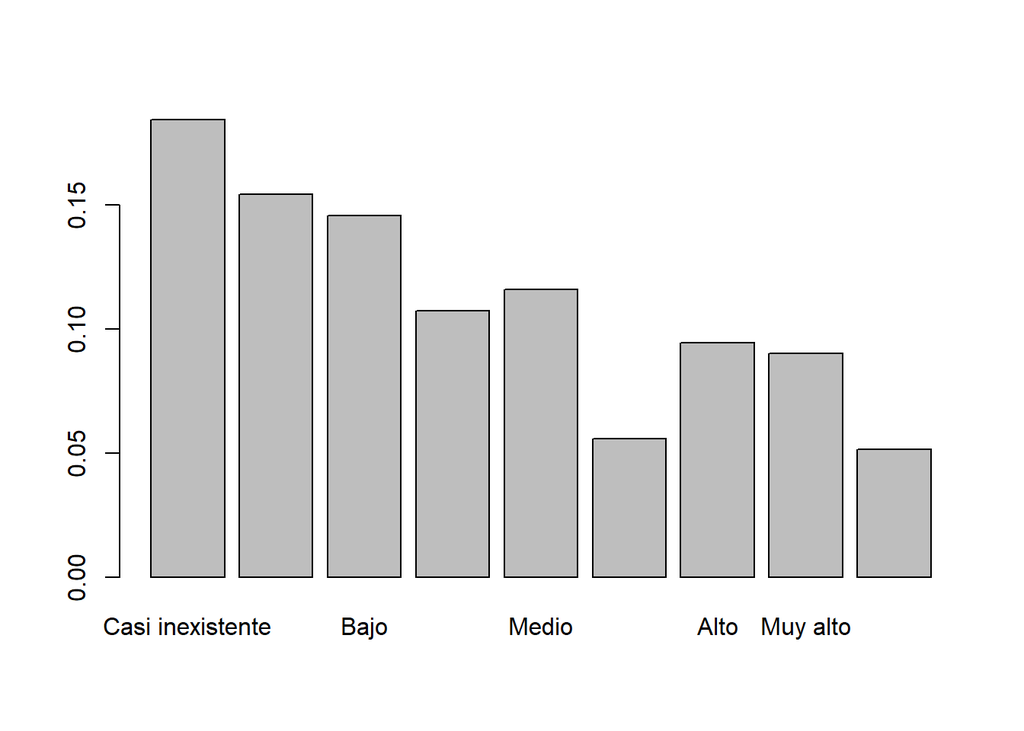

```r
barplot(prop.table(table(alldata$Empleovul3)))
```

### Eliminación del indicador numérico del que se creó la variable categórica

```r
library(dplyr)
alldata = alldata [, -c(4,5)]
```

## 6. Scrapping de la base de datos del Índice de Desarrollo Humano 2019

- Enlace: https://datosmacro.expansion.com/idh

```r
library(rvest)
url="https://datosmacro.expansion.com/idh"
pagina_web=read_html(url)
pagina_web
```

```
## {html_document}
## <html lang="es" dir="ltr" prefix="content: http://purl.org/rss/1.0/modules/content/  dc: http://purl.org/dc/terms/  foaf: http://xmlns.com/foaf/0.1/  rdfs: http://www.w3.org/2000/01/rdf-schema#  sioc: http://rdfs.org/sioc/ns#  sioct: http://rdfs.org/sioc/types#  skos: http://www.w3.org/2004/02/sk…
## [1] <head>\n<meta http-equiv="Content-Type" content="text/html; charset=UTF-8 ...
## [2] <body itemscope itemtype="https://schema.org/WebPage" class="path-node pa ...
```

- Buscamos el css:

```r
css_nombre="tr"
nombre_html <- html_nodes(pagina_web,css_nombre)
nombre_texto <- html_text(nombre_html)
head(nombre_texto)
```

```
## [1] "PaísesIDHRanking IDHVar."  "España [+]0,90425º0"
## [3] "Alemania [+]0,9476º2"      "Reino Unido [+]0,93213º-1"
## [5] "Francia [+]0,90126º0"      "Italia [+]0,89229º0"
```

- Armamos la base de datos

```r
IDH <- data.frame("pais" = nombre_texto)
head(IDH)
```

```
##                        pais
## 1  PaísesIDHRanking IDHVar.
## 2       España [+]0,90425º0
## 3      Alemania [+]0,9476º2
## 4 Reino Unido [+]0,93213º-1
## 5      Francia [+]0,90126º0
## 6       Italia [+]0,89229º0
```

## 7. Formateo y limpeza de la base de datos del IDH

- Creación de los nombres de los países

```r
IDH$Países=gsub('[[:punct:]]',"",IDH$pais)
```

```r
library("stringr")
IDH$Países=str_split(string = IDH$Países,
                         pattern = " 0",
                         simplify = T)[,1]
```

- Creación de los niveles de idh

```r
#Eliminamos los nombres de los países
IDH$idh=gsub('[[:alpha:]]',"",IDH$pais)
```

```r
#Agregamos un nuevos patrón
IDH$idh=gsub('0,',"aa0,",IDH$idh)
```

```r
#Creamos la nueva columna
IDH$idh=str_split(string = IDH$idh,
                         pattern = "aa",
                         simplify = T)[,2]
```

```r
#Cambiamos la coma "," por le punto "." para facilitar futuras operaciones
IDH$idh=gsub(',',".",IDH$idh)
```

```r
# Nos quedamos con los 5 primeros dígitos
IDH$idh= substr(IDH$idh,1,5)
```

- Limpieza de columnas y formateo de las variables

```r
#Elimino la primera fila y primera columna
IDH = IDH[-c(1),]
IDH = IDH[,-c(1)]

#Le doy reset a los rownames
row.names(IDH) = NULL
```

```r
# convertimos nuestras variables faltantes en numéricas
IDH$idh=as.numeric(IDH$idh)
str(IDH$idh)
```

```
##  num [1:189] 0.904 0.947 0.932 0.901 0.892 0.864 0.926 0.919 0.761 0.868 ...
```

## 8. Integración de la base de datos “alldata” y “IDH”

```r
#versión RIGHT JOIN
BASEFINAL=merge(alldata,IDH,all.y = TRUE)
str(BASEFINAL)
```

```
## 'data.frame':    189 obs. of  5 variables:
##  $ Países      : chr  "Afganistán" "Albania" "Alemania" "Andorra" ...
##  $ Poblacionact: num  10382034 1421853 44351163 NA 13116712 ...
##  $ Empleadores : num  2.83 3.07 4.26 NA 4.81 ...
##  $ Empleovul3  : Factor w/ 9 levels "Casi inexistente",..: 8 5 1 NA 8 NA 1 3 3 4 ...
##  $ idh         : num  0.511 0.795 0.947 0.868 0.581 0.778 0.854 0.748 0.845 0.776 ...
```

- JUSTIFICACIÓN: En este caso se utilizó el “merge” en la versión “right”, debido a que la base de datos “alldata” tenía información de grupos de países como observación. Se los hubiera considerado, realizar futuros cálculos como el promedio no hubieran salido exactos.Asimismo, así me acerco mucho más al número real de países.

```r
##Elimino los datos perdidos

BASEFINAL=na.omit(BASEFINAL)
any(is.na(BASEFINAL))
```

```
## [1] FALSE
```

# PARTE II: ELABORACIÓN DEL REPORTE

Título: Análisis sobre la protección social y el trabajo en China

Introducción:

Actualmente ya no podemos desconocer el papel de China dentro del escenario internacional. Este país, junto con Rusia, ha sido catalogado por la literatura occidental como una potencia revisionista, debido a que su irrupción en el sistema internacional ha representado una amenaza para la posición hegemónica que por muchos años ha mantenido Estados Unidos. Sin embargo, para la Ciencia Política también es necesario poder centrarnos en los procesos y fenómenos internos, debido a que nos muestran un panorama más completo del desarrollo de cada país.

Este trabajo tiene como objetivo analizar los avances de China en materia de protección social y trabajo. De manera que podamos conocer si este rubro representa uno de las prioridades del estado Chino. Para acercanos al panorama laborar del China, se ha seleccionado tres (03) indicadores: el porcentaje del empleadores en China, el porcentaje de empleo vulnerable y la población activa total de este país.

Descripción de los indicadores seleccionados:

- **Empleadores, total (% del empleo total)**: Empleadores se refiere a aquellos trabajadores que, por cuenta propia o con unos pocos asociados, mantienen el tipo de trabajo que se define como “empleo por cuenta propia”, es decir: trabajos en los que la remuneración depende directamente de las utilidades derivadas de los bienes y servicios producidos, y que, en esta capacidad, han comprometido a una o más personas para trabajar con ellos como empleado(s) de manera continua.

Fuente: Indicadores clave del mercado de trabajo ( KILM, por sus siglas en inglés ) de la OIT.

- **Empleo vulnerable, total (% del total de empleo)**: El empleo vulnerable se refiere a los trabajadores familiares no remunerados y a los trabajadores autónomos como porcentaje del empleo total.

Fuente: Organización Internacional del Trabajo, base de datos de Indicadores principales sobre el mercado laboral.

- **Población activa, total**: La población activa total comprende a personas de 15 años o más que satisfacen la definición de la Organización Internacional del Trabajo de población económicamente activa: todas las personas que aportan trabajo para la producción de bienes y servicios durante un período específico. Incluye tanto a las personas con empleo como a las personas desempleadas. Si bien las prácticas nacionales varían en el tratamiento de grupos como las fuerzas armadas o los trabajadores estacionales o a tiempo parcial, en general, la población activa incluye a las fuerzas armadas, a los desempleados, a los que buscan su primer trabajo, pero excluye a quienes se dedican al cuidado del hogar y a otros trabajadores y cuidadores no remunerados.

Fuente: Organización Internacional del Trabajo, base de datos de Indicadores principales sobre el mercado laboral.

## Tabla del promedio mundial de los indicadores

```
## 'data.frame':    135 obs. of  5 variables:
##  $ Países      : chr  "Afganistán" "Albania" "Alemania" "Angola" ...
##  $ Poblacionact: num  10382034 1421853 44351163 13116712 15145863 ...
##  $ Empleadores : num  2.83 3.07 4.26 4.81 1.73 ...
##  $ Empleovul3  : Factor w/ 9 levels "Casi inexistente",..: 8 5 1 8 1 3 3 4 2 1 ...
##  $ idh         : num  0.511 0.795 0.947 0.581 0.854 0.748 0.845 0.776 0.944 0.922 ...
##  - attr(*, "na.action")= 'omit' Named int [1:54] 4 6 15 17 20 21 22 25 27 31 ...
##   ..- attr(*, "names")= chr [1:54] "4" "6" "15" "17" ...
```

```
##           PROMEDIO Promedio_Poblacionact Promedio_Empleadores Promedio_IDH
## 1 PROMEDIO MUNDIAL              21592922             3.360815    0.7330741
## 2            CHINA             800020955             2.110000    0.7610000
```

## La relación del IDH con el procetanje de empleadores en cada país

Si aplicamos una correlación entre estas dos variables tendremos el siguiente resultado:

```
## [1] 0.3499156
```

Esto quiere decir que existe una relación pequeña entre ambas variables y que esta es positiva. Es decir, mientras más empleadores existen en un país, mejor será el índice de desarrollo humano. Para ver si los datos tiene ese comportamiento podemos mostrarun gráficos de dispersión de puntos:

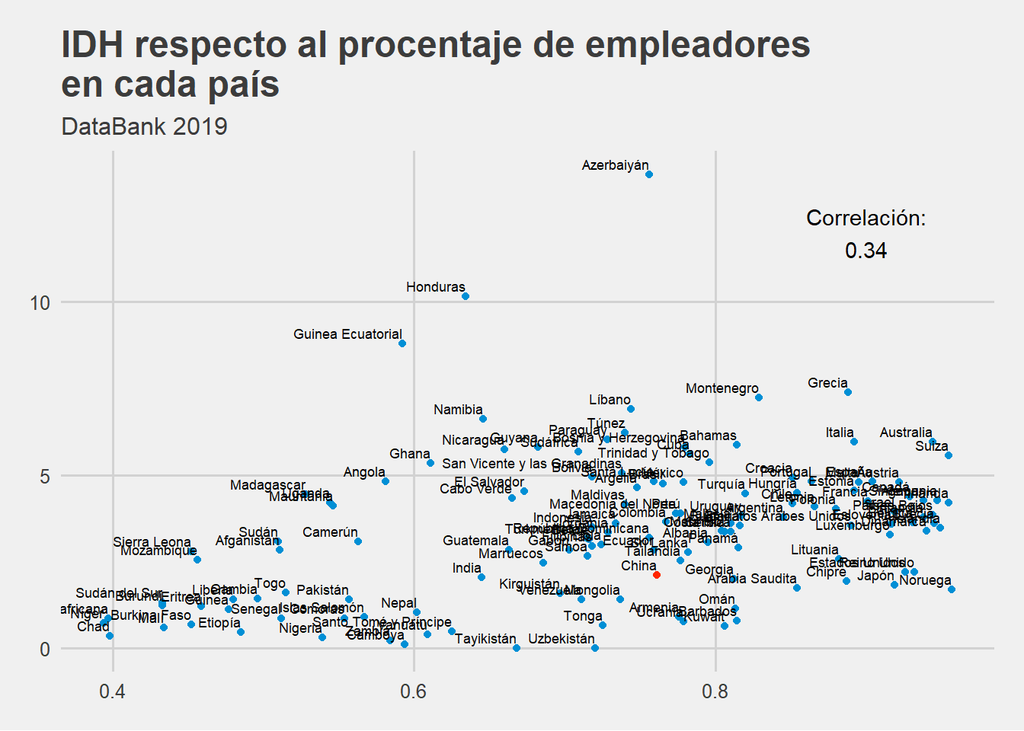

El gráfico confirma que existe esa relación pequeña entre el IDH y el procentaje de empleadores en cada páis. Asimismo, el gráfico nos da otros alcances porque podemos observar que los países con un índice de desarrollo humano como japón, Noruega, Suiza, Luxemburgo, entre otros,se concentran en el lado derecho inferior del gráfico y, contrarioa ello, los países africanos con menor IDH se ubican en la parte izquierda inferior de la tabla. Esto nos indicaría que un mayor procentaje de empleadores en un país no necesariamente conduce a la mejora de la calidad de vida de las personas, sino que puede responder a la formalización y/o a otras formas de ingresar al empleo como aquellas que proporcionan los Estados.

Asimismo, se observa en el punto rojo la posición de China.Si bien no supera el 0.8 de IDH, se encuentra dentro del grupo de países como México, Ecuador y Colombia. Es decir, que su idh y la cantidad de procentaje de empleadores es similar a la de los países centro y sudamericanos. Detrás aún de los países europeos y nórdicos. Se sigue concluyendo en esta parte que un mejor bienestar ciudadano no necesariamente implica con más personas que puedan emplear. Esto puede responder a la calidad o tipo de trabajo que predomine o se de en un país. Por ese motivo, para complejizar el análisis adicionaremos el nivel de empleo vulnerable en los países.

## Países según el nivel de empleo vulnerable

[output not shown]

```
## 'data.frame':    123 obs. of  9 variables:
##  $ Países      : chr  "Afganistán" "Albania" "Alemania" "Angola" ...
##  $ Poblacionact: num  10382034 1421853 44351163 13116712 15145863 ...
##  $ Empleadores : num  2.83 3.07 4.26 4.81 1.73 ...
##  $ Empleovul3  : Factor w/ 9 levels "Casi inexistente",..: 8 5 1 8 1 3 4 2 1 1 ...
##  $ idh         : num  0.511 0.795 0.947 0.581 0.854 0.845 0.776 0.944 0.922 0.814 ...
##  $ atipico     : Factor w/ 2 levels "0","1": 1 1 1 1 1 1 1 1 1 1 ...
##  $ name        : chr  "Afghanistan" "Albania" "Germany" "Angola" ...
##  $ iso3        : chr  "AFG" "ALB" "DEU" "AGO" ...
##  $ phone_code  : chr  "93" "355" "49" "244" ...
```

Los trabajos no remunerados o que corresponden alguna vulnerabilidad económica para la persona tendría que tener relación con el Índice del Desarrollo Humano. Así como vimos que los países europeos y nórdicos se agruparon en el gráfico anterior, se espera que se refleje lo mismo respecto al empleo vulnerable (% del total del empleo) y que nos permita comprender los niveles de desarrollo los países en función de la protacción social y trabajo en cada uno de ellos, especialmente en China que es nuestro caso de mayor interés.

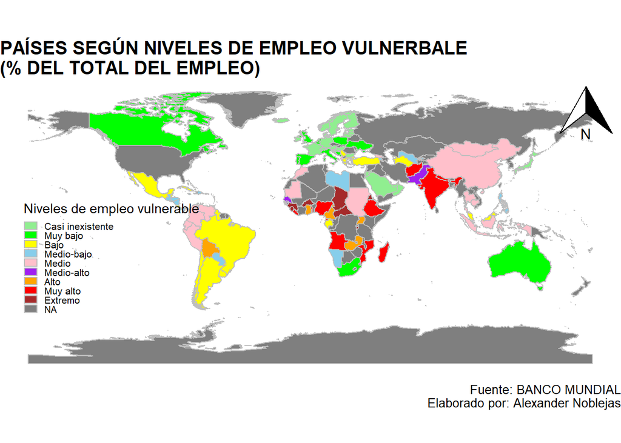

En cuanto a China, se observa que, al igual que varios países del continente asiático, se ubican en el nivel medio; es decir, los niveles de empleo vulnerable en China se encuentran entre el 42% y 52.5% del total. Asimismo, se evidencia que se trata de una característica más o menos recurrente en la región asiática oriental con tendencia reducir esos niveles.

Bajo el panorama mundial, el avance de China -potencia mundial- en temas de protección social y trabajo se encuentra a niveles similares que países en vías de desarrollo del continente Sudaméricano en casos como Perú, Ecuador y Colombia. Aunque también hay casos con mejores niveles que China, tales como Chile, Argentina, Uruguay y Brasil.

### GRÁFICO 3: GRÁFICO DE DENSIDAD DE LA POBLACIÓN ECONÓMICAMWNTE ACTIVA

- Estadísticos descriptivos de la variable “Población activa”:

```
##      Min.   1st Qu.    Median      Mean   3rd Qu.      Max.
##     31687   1439472   4238924  21592922  13137960 800020955
```

Los estadísticos descriptivos nos indican que a nivel mundial existe una gran diferencia en la cantidad de población activa entre los países. Por un ado se identifica CHINA como el pais que más población económicamente activa tiene con un total de 800020955 personas. Por otro lado, se reconoce a Tonga como el país que menos población activa posee con un total de 31687 personas.

Asimismo, vemos que en promedio existen 21592922 personas economicamente activas entre los países del mundo. Lo que nos indica la importancia de seguir analizando este factor dentro de los países. Lo mencionado podemos verlo en un gráfico de densidad:

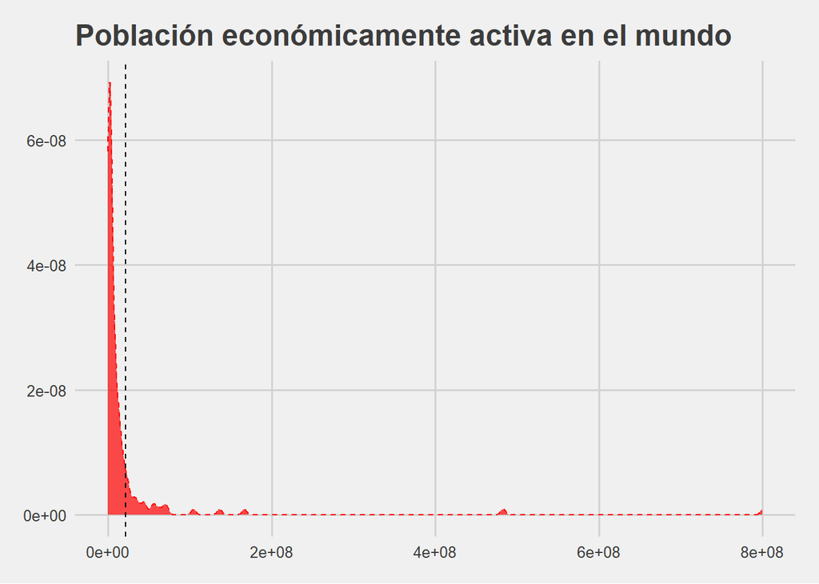

El grafico de densidad también nos muestra enorme la diferencia en cuanto al número de población económicamente activa en el mundo. Hay mucha más concetración de países cuyo número de población economicamente activa es menor a la del promedio mundial (21592922 personas), tal como indica la línea vertical. Más bien, existen una gran diferencia en cuanto a aquellos países como China, India y Estados Unidos (los tres países importantes en la economía mundial) con una inmensa cantidad de población activa que superan los 160 millones de personas y aquellos que tiene muy poca como Tonga, Samo y San Vicente que no superan los 60 mil.

### Gráfico de barras de los niveles de de empleo vulnerable en el mundo

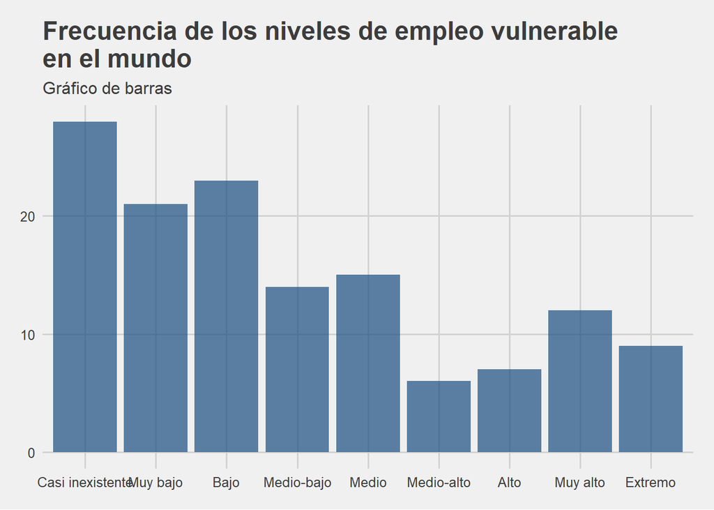

```r
library(ggplot2)
library(ggthemes)
ggplot(BASEFINAL, aes(x = Empleovul3)) +
  geom_bar(width = 0.9,  fill=rgb(0.1,0.3,0.5,0.7)) +
  scale_x_discrete("Empleo vulnerable") +     # Eje X
  scale_y_continuous("Frecuencia") +          # Eje y
  labs(title = "Frecuencia de los niveles de empleo vulnerable
en el mundo",
       subtitle = "Gráfico de barras") +

   theme_fivethirtyeight()
```